# Prediction Assignment

Paul Houghton

Wednesday, July 22, 2015

# Introduction

The practical machine learning Course project takes the data from the source: http://groupware.les.inf.puc-rio.br/har to try an predict how well subjects (6 in the study) completed the exercises. Subjects were ask to complete an exercise in 5 different manners (as described in the source link) The final goal of the prediction model is to *“predict the manner in which they did the exercise”*. The exercises were performed and classified as follows: *exactly according to the specification (Class A)* throwing the elbows to the front (Class B) *lifting the dumbbell only halfway (Class C)* lowering the dumbbell only halfway (Class D) *throwing the hips to the front (Class E) Class A matches to the specified execution of the exercise, while the other 4 classes correspond to common mistakes.

## Data loading

The first step in the process is to download the data from the links provided and confirm that the training and testing match. The required r packages were also loaded in this step.

```r
library('caret'); library('rattle'); library('rpart.plot'); library('randomForest'); #library('AppliedPredictiveModeling')
#download the training and test data. read into data objects
trainingURL <- 'https://d396qusza40orc.cloudfront.net/predmachlearn/pml-training.csv'
testURL <- 'https://d396qusza40orc.cloudfront.net/predmachlearn/pml-training.csv'
if (!file.exists('pml-training.csv')) download.file(trainingURL, 'pml-training.csv') else 'test data present'
```

```
## [1] "test data present"
```

```r
if (!file.exists('pml-test.csv')) download.file(testURL, 'pml-test.csv') else 'training data present'
```

```
## [1] "training data present"
```

```r
data <- read.csv('pml-training.csv')
colnames_data <- colnames(data)
test <- read.csv('pml-test.csv')
colnames_test <- colnames(test)

#Confirm both the training and testing data set column names are the same, (excluding the object in each)
equal <- all.equal(colnames_data[1:length(colnames_data)-1], colnames_test[1:length(colnames_test)-1])


if (equal) "Data sets match" else "Data sets don't match"
```

```
## [1] "Data sets match"
```

```r
rm(trainingURL, testURL)
```

## Feature Preparation

The process of preparing and deciding on features is the next step. First a check was done to find null fields (where no data has been entered for any action) and remove them from the data set. This was done to manage the data size.

```r
#Data Set Preparation.
# Count the number of non-NAs in each col.
nonNAs <- function(x) {
    as.vector(apply(x, 2, function(x) length(which(!is.na(x)))))
}
##build a vector of columns with missing data to drop
colcnts <- nonNAs(data)
drops <- c()
for (cnt in 1:length(colcnts)) {
    if (colcnts[cnt] < nrow(data)) {
        drops <- c(drops, colnames_data[cnt])
    }
}

# Drop NA data and the first 7 columns as they're unnecessary for predicting.
data <- data[,!(names(data) %in% drops)]
data <- data[,8:length(colnames(data))]
```

In the lecture notes there are 2 levels of covariate creation strategies, Level 1 (raw data to covariate) is not required in this project as we are supplied with raw sensor data. The level 2 straegy (covariates to new covariates) is worth completing while being mindful of overfitting. The first step in this process is to check for covariate variability

```r
#Identify covariates that have near zero variablility for removal
nsv <- nearZeroVar(data, saveMetrics=TRUE)
# nsv
#Identify covariates that have near zero variablility for removal
nsv <- nearZeroVar(data, saveMetrics=TRUE)
nsvkeep <- nsv[nsv$nzv == F,]
nsvkeep <- rownames(nsvkeep)
data <- data[,nsvkeep]
```

Using the nearZeroVar function in the Caret package covatiates which lack variability, nzv == TRUE, were identified and removed from the dataset.

The provided data was broken into 4 subsets each with a 60/40 split for training and practice testing as below. This was done to allow for more iterations of the training to take place.

```r
# Divide the given training set into 4 roughly equal sets.
set.seed(9874653)
ids_small <- createDataPartition(y=data$classe, p=0.25, list=FALSE)
small_1 <- data[ids_small,]
remainder <- data[-ids_small,]
set.seed(9874653)
ids_small <- createDataPartition(y=remainder$classe, p=0.33, list=FALSE)
small_2 <- remainder[ids_small,]
remainder <- remainder[-ids_small,]
set.seed(9874653)
ids_small <- createDataPartition(y=remainder$classe, p=0.5, list=FALSE)
small_3 <- remainder[ids_small,]
small_4 <- remainder[-ids_small,]
# Divide each of these 4 sets into training (60%) and test (40%) sets.
set.seed(9874653)
inTrain <- createDataPartition(y=small_1$classe, p=0.6, list=FALSE)
training_small_1 <- small_1[inTrain,]
test_small_1 <- small_1[-inTrain,]
set.seed(9874653)
inTrain <- createDataPartition(y=small_2$classe, p=0.6, list=FALSE)
training_small_2 <- small_2[inTrain,]
test_small_2 <- small_2[-inTrain,]
set.seed(9874653)
inTrain <- createDataPartition(y=small_3$classe, p=0.6, list=FALSE)
training_small_3 <- small_3[inTrain,]
test_small_3 <- small_3[-inTrain,]
set.seed(9874653)
inTrain <- createDataPartition(y=small_4$classe, p=0.6, list=FALSE)
training_small_4 <- small_4[inTrain,]
test_small_4 <- small_4[-inTrain,]
```

## Algorithm

Based on the Paper [Velloso, E.; Bulling, A.; Gellersen, H.; Ugulino, W.; Fuks, H. Qualitative Activity Recognition of Weight Lifting Exercises. Proceedings of 4th International Conference in Cooperation with SIGCHI (Augmented Human ’13) . Stuttgart, Germany: ACM SIGCHI, 2013.](http://groupware.les.inf.puc-rio.br/public/papers/2013.Velloso.QAR-WLE.pdf), Section 5.2 and the discussions on the Coursera Forums the algorithms selected were classification Trees (CART) (method=rpart) and random forest (method=rf) both taken from the caret package implementation.

## Parameters

The CART (method=rpart) parameters was to be taken from the default settings initially, followed by preprocessing and cross validation to improve accuracy.

While testing against the default settings for the random forest (method=rf) would have been good for consistancy, forum research suggested the processing time required would be extremely lengthy, especially knowing the accuracy wouldn’t be good. As such, random forests were completed with cross validation and preprocessing where valuable.

## Evaluation

### CART (method = rpart)

Training with the default parameters:

```r
#Tree 1 - Default Settings
set.seed(8746)
tree_1 <- train(training_small_1$classe ~ ., data = training_small_1, method= 'rpart')
print(tree_1, digits=3)
```

```
## CART
##
## 2946 samples
##   52 predictor
##    5 classes: 'A', 'B', 'C', 'D', 'E'
##
## No pre-processing
## Resampling: Bootstrapped (25 reps)
## Summary of sample sizes: 2946, 2946, 2946, 2946, 2946, 2946, ...
## Resampling results across tuning parameters:
##
##   cp      Accuracy  Kappa   Accuracy SD  Kappa SD
##   0.0282  0.569     0.4556  0.0360       0.0462
##   0.0409  0.512     0.3740  0.0435       0.0675
##   0.1067  0.342     0.0881  0.0372       0.0511
##
## Accuracy was used to select the optimal model using  the largest value.
## The final value used for the model was cp = 0.0282.
```

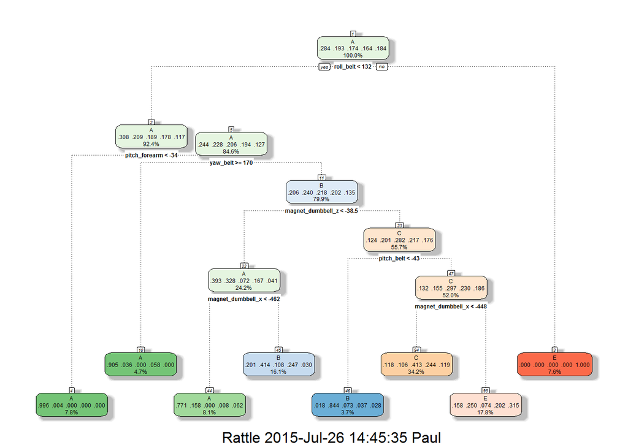

```r
fancyRpartPlot(tree_1$finalModel, digits=3)
```

```r
#Tree 1 - Evaluated against Test set 1
set.seed(8746)
predictions_1 <- predict(tree_1, newdata=test_small_1)
print(confusionMatrix(predictions_1, test_small_1$classe), digits=3)
```

```
## Confusion Matrix and Statistics
##
##           Reference
## Prediction   A   B   C   D   E
##          A 330  41   1   7   7
##          B  65 161  45  92  17
##          C  89  75 279 156  90
##          D   0   0   0   0   0
##          E  74 103  17  66 246
##
## Overall Statistics
##
##                Accuracy : 0.518
##                  95% CI : (0.496, 0.54)
##     No Information Rate : 0.285
##     P-Value [Acc > NIR] : <2e-16
##
##                   Kappa : 0.396
##  Mcnemar's Test P-Value : <2e-16
##
## Statistics by Class:
##
##                      Class: A Class: B Class: C Class: D Class: E
## Sensitivity             0.591   0.4237    0.816    0.000    0.683
## Specificity             0.960   0.8615    0.747    1.000    0.838
## Pos Pred Value          0.855   0.4237    0.405      NaN    0.486
## Neg Pred Value          0.855   0.8615    0.950    0.836    0.922
## Prevalence              0.285   0.1938    0.174    0.164    0.184
## Detection Rate          0.168   0.0821    0.142    0.000    0.125
## Detection Prevalence    0.197   0.1938    0.351    0.000    0.258
## Balanced Accuracy       0.776   0.6426    0.781    0.500    0.760
```

The results of the default CART were rather poor (0.518), showing further processing was required.

```r
#Tree 2 - preprocessing only
set.seed(8746)
tree <- train(training_small_1$classe ~ ., preProcess=c('center', 'scale'), data = training_small_1, method= 'rpart')
print(tree, digits=3)
```

```
## CART
##
## 2946 samples
##   52 predictor
##    5 classes: 'A', 'B', 'C', 'D', 'E'
##
## Pre-processing: centered, scaled
## Resampling: Bootstrapped (25 reps)
## Summary of sample sizes: 2946, 2946, 2946, 2946, 2946, 2946, ...
## Resampling results across tuning parameters:
##
##   cp      Accuracy  Kappa   Accuracy SD  Kappa SD
##   0.0282  0.569     0.4556  0.0360       0.0463
##   0.0409  0.512     0.3739  0.0434       0.0675
##   0.1067  0.342     0.0881  0.0372       0.0511
##
## Accuracy was used to select the optimal model using  the largest value.
## The final value used for the model was cp = 0.0282.
```

```r
#Tree 3 - cross validation only
set.seed(8746)
tree <- train(training_small_1$classe ~ ., trControl=trainControl(method = "cv", number = 4), data = training_small_1, method= 'rpart')
print(tree, digits=3)
```

```
## CART
##
## 2946 samples
##   52 predictor
##    5 classes: 'A', 'B', 'C', 'D', 'E'
##
## No pre-processing
## Resampling: Cross-Validated (4 fold)
## Summary of sample sizes: 2212, 2210, 2207, 2209
## Resampling results across tuning parameters:
##
##   cp      Accuracy  Kappa   Accuracy SD  Kappa SD
##   0.0282  0.550     0.4338  0.0243       0.0265
##   0.0409  0.525     0.4024  0.0134       0.0154
##   0.1067  0.339     0.0837  0.0370       0.0560
##
## Accuracy was used to select the optimal model using  the largest value.
## The final value used for the model was cp = 0.0282.
```

```r
#Tree 4 - both Preprocessing and cross validation
set.seed(8746)
tree <- train(training_small_1$classe ~ ., preProcess=c('center', 'scale'),trControl=trainControl(method = "cv", number = 4), data = training_small_1, method= 'rpart')
print(tree, digits=3)
```

```
## CART
##
## 2946 samples
##   52 predictor
##    5 classes: 'A', 'B', 'C', 'D', 'E'
##
## Pre-processing: centered, scaled
## Resampling: Cross-Validated (4 fold)
## Summary of sample sizes: 2212, 2210, 2207, 2209
## Resampling results across tuning parameters:
##
##   cp      Accuracy  Kappa   Accuracy SD  Kappa SD
##   0.0282  0.550     0.4338  0.0243       0.0265
##   0.0409  0.525     0.4024  0.0134       0.0154
##   0.1067  0.339     0.0837  0.0370       0.0560
##
## Accuracy was used to select the optimal model using  the largest value.
## The final value used for the model was cp = 0.0282.
```

```r
#Tree 4 - Evaluated against Test set 1
set.seed(8746)
tree_predictions <- predict(tree, newdata=test_small_1)
print(confusionMatrix(tree_predictions, test_small_1$classe), digits=3)
```

```
## Confusion Matrix and Statistics
##
##           Reference
## Prediction   A   B   C   D   E
##          A 330  41   1   7   7
##          B  65 161  45  92  17
##          C  89  75 279 156  90
##          D   0   0   0   0   0
##          E  74 103  17  66 246
##
## Overall Statistics
##
##                Accuracy : 0.518
##                  95% CI : (0.496, 0.54)
##     No Information Rate : 0.285
##     P-Value [Acc > NIR] : <2e-16
##
##                   Kappa : 0.396
##  Mcnemar's Test P-Value : <2e-16
##
## Statistics by Class:
##
##                      Class: A Class: B Class: C Class: D Class: E
## Sensitivity             0.591   0.4237    0.816    0.000    0.683
## Specificity             0.960   0.8615    0.747    1.000    0.838
## Pos Pred Value          0.855   0.4237    0.405      NaN    0.486
## Neg Pred Value          0.855   0.8615    0.950    0.836    0.922
## Prevalence              0.285   0.1938    0.174    0.164    0.184
## Detection Rate          0.168   0.0821    0.142    0.000    0.125
## Detection Prevalence    0.197   0.1938    0.351    0.000    0.258
## Balanced Accuracy       0.776   0.6426    0.781    0.500    0.760
```

When both preprocessing and cross validation was incorportated no improvment over the default settings was found (0.518 default, 0.518 with preprocessing & CV). Because there was no negative impact it was decided to keep both preprocessing and cross validation for testing against the final set.

### Random Forest (method=rf)

The second alogrithm used was a random forest. based on advice on the Coursera forums processing time against non processed data sets was a barrier so I started by testing against cross validated methods to deterimine the impact of preprocessing.

```r
##Random Forest Training
#Forest 1.1 - Train on training set 1 with only cross validation.
set.seed(9856)
forest <- train(training_small_1$classe ~ ., method="rf", trControl=trainControl(method = "cv", number = 4), data=training_small_1)
print(forest, digits=3)
```

```
## Random Forest
##
## 2946 samples
##   52 predictor
##    5 classes: 'A', 'B', 'C', 'D', 'E'
##
## No pre-processing
## Resampling: Cross-Validated (4 fold)
## Summary of sample sizes: 2211, 2209, 2208, 2210
## Resampling results across tuning parameters:
##
##   mtry  Accuracy  Kappa  Accuracy SD  Kappa SD
##    2    0.959     0.948  0.00593      0.00752
##   27    0.964     0.954  0.00274      0.00347
##   52    0.957     0.946  0.00650      0.00820
##
## Accuracy was used to select the optimal model using  the largest value.
## The final value used for the model was mtry = 27.
```

```r
#Forest 1.1 - Evaluate against test set
predictions <- predict(forest, newdata=test_small_1)
print(confusionMatrix(predictions, test_small_1$classe), digits=4)
```

```
## Confusion Matrix and Statistics
##
##           Reference
## Prediction   A   B   C   D   E
##          A 553  11   0   1   0
##          B   2 358   8   0   4
##          C   2   7 327   5   5
##          D   1   3   7 315   2
##          E   0   1   0   0 349
##
## Overall Statistics
##
##                Accuracy : 0.9699
##                  95% CI : (0.9614, 0.977)
##     No Information Rate : 0.2845
##     P-Value [Acc > NIR] : < 2.2e-16
##
##                   Kappa : 0.9619
##  Mcnemar's Test P-Value : NA
##
## Statistics by Class:
##
##                      Class: A Class: B Class: C Class: D Class: E
## Sensitivity            0.9910   0.9421   0.9561   0.9813   0.9694
## Specificity            0.9914   0.9911   0.9883   0.9921   0.9994
## Pos Pred Value         0.9788   0.9624   0.9451   0.9604   0.9971
## Neg Pred Value         0.9964   0.9862   0.9907   0.9963   0.9932
## Prevalence             0.2845   0.1938   0.1744   0.1637   0.1836
## Detection Rate         0.2820   0.1826   0.1668   0.1606   0.1780
## Detection Prevalence   0.2881   0.1897   0.1764   0.1673   0.1785
## Balanced Accuracy      0.9912   0.9666   0.9722   0.9867   0.9844
```

```r
#Forest 1.2 - Train on training set 1 with cross validation and preprocessiing.
set.seed(9856)
forest <- train(training_small_1$classe ~ ., preProcess=c("center", "scale"), method="rf", trControl=trainControl(method = "cv", number = 4), data=training_small_1)
print(forest, digits=3)
```

```
## Random Forest
##
## 2946 samples
##   52 predictor
##    5 classes: 'A', 'B', 'C', 'D', 'E'
##
## Pre-processing: centered, scaled
## Resampling: Cross-Validated (4 fold)
## Summary of sample sizes: 2211, 2209, 2208, 2210
## Resampling results across tuning parameters:
##
##   mtry  Accuracy  Kappa  Accuracy SD  Kappa SD
##    2    0.957     0.946  0.00423      0.00535
##   27    0.964     0.954  0.00276      0.00349
##   52    0.958     0.947  0.00799      0.01010
##
## Accuracy was used to select the optimal model using  the largest value.
## The final value used for the model was mtry = 27.
```

```r
#Forest 1.2 - Evaluate against test set
predictions <- predict(forest, newdata=test_small_1)
print(confusionMatrix(predictions, test_small_1$classe), digits=4)
```

```
## Confusion Matrix and Statistics
##
##           Reference
## Prediction   A   B   C   D   E
##          A 554  11   0   1   0
##          B   2 358   8   0   3
##          C   2   7 326   5   6
##          D   0   3   8 315   2
##          E   0   1   0   0 349
##
## Overall Statistics
##
##                Accuracy : 0.9699
##                  95% CI : (0.9614, 0.977)
##     No Information Rate : 0.2845
##     P-Value [Acc > NIR] : < 2.2e-16
##
##                   Kappa : 0.9619
##  Mcnemar's Test P-Value : NA
##
## Statistics by Class:
##
##                      Class: A Class: B Class: C Class: D Class: E
## Sensitivity            0.9928   0.9421   0.9532   0.9813   0.9694
## Specificity            0.9914   0.9918   0.9876   0.9921   0.9994
## Pos Pred Value         0.9788   0.9650   0.9422   0.9604   0.9971
## Neg Pred Value         0.9971   0.9862   0.9901   0.9963   0.9932
## Prevalence             0.2845   0.1938   0.1744   0.1637   0.1836
## Detection Rate         0.2825   0.1826   0.1662   0.1606   0.1780
## Detection Prevalence   0.2886   0.1892   0.1764   0.1673   0.1785
## Balanced Accuracy      0.9921   0.9669   0.9704   0.9867   0.9844
```

This comparasion shows there is no significant impact between the two processes but because there was no negative impact it was decided to keep both preprocessing and cross validation for testing against the final set.

```r
#Forest 2 - Train on training set 2 with cross validation and preprocessiing.
set.seed(9856)
forest <- train(training_small_2$classe ~ ., preProcess=c("center", "scale"), method="rf", trControl=trainControl(method = "cv", number = 4), data=training_small_2)
print(forest, digits=3)
```

```
## Random Forest
##
## 2917 samples
##   52 predictor
##    5 classes: 'A', 'B', 'C', 'D', 'E'
##
## Pre-processing: centered, scaled
## Resampling: Cross-Validated (4 fold)
## Summary of sample sizes: 2189, 2187, 2187, 2188
## Resampling results across tuning parameters:
##
##   mtry  Accuracy  Kappa  Accuracy SD  Kappa SD
##    2    0.947     0.932  0.00442      0.00565
##   27    0.950     0.937  0.00999      0.01268
##   52    0.941     0.925  0.01119      0.01421
##
## Accuracy was used to select the optimal model using  the largest value.
## The final value used for the model was mtry = 27.
```

```r
#Forest 2 - Evaluate against test set
predictions <- predict(forest, newdata=test_small_2)
print(confusionMatrix(predictions, test_small_2$classe), digits=4)
```

```
## Confusion Matrix and Statistics
##
##           Reference
## Prediction   A   B   C   D   E
##          A 540  12   0   1   0
##          B  10 346   3   0   3
##          C   1  15 325   8   1
##          D   1   3   7 309   7
##          E   0   0   3   0 346
##
## Overall Statistics
##
##                Accuracy : 0.9614
##                  95% CI : (0.9518, 0.9695)
##     No Information Rate : 0.2844
##     P-Value [Acc > NIR] : < 2.2e-16
##
##                   Kappa : 0.9511
##  Mcnemar's Test P-Value : NA
##
## Statistics by Class:
##
##                      Class: A Class: B Class: C Class: D Class: E
## Sensitivity            0.9783   0.9202   0.9615   0.9717   0.9692
## Specificity            0.9906   0.9898   0.9844   0.9889   0.9981
## Pos Pred Value         0.9765   0.9558   0.9286   0.9450   0.9914
## Neg Pred Value         0.9914   0.9810   0.9918   0.9944   0.9931
## Prevalence             0.2844   0.1937   0.1741   0.1638   0.1839
## Detection Rate         0.2782   0.1783   0.1674   0.1592   0.1783
## Detection Prevalence   0.2849   0.1865   0.1803   0.1685   0.1798
## Balanced Accuracy      0.9845   0.9550   0.9730   0.9803   0.9836
```

```r
#Test Forest 2 against provided test set
print(predict(forest, newdata = test))
```

```
##  [1] B A B A A E D B A A B C B A E E A B B B
## Levels: A B C D E
```

```r
#Forest 3 - Train on training set 2 with cross validation and preprocessiing.
set.seed(9856)
forest <- train(training_small_3$classe ~ ., preProcess=c("center", "scale"), method="rf", trControl=trainControl(method = "cv", number = 4), data=training_small_3)
print(forest, digits=3)
```

```
## Random Forest
##
## 2960 samples
##   52 predictor
##    5 classes: 'A', 'B', 'C', 'D', 'E'
##
## Pre-processing: centered, scaled
## Resampling: Cross-Validated (4 fold)
## Summary of sample sizes: 2221, 2220, 2219, 2220
## Resampling results across tuning parameters:
##
##   mtry  Accuracy  Kappa  Accuracy SD  Kappa SD
##    2    0.951     0.938  0.00518      0.00659
##   27    0.950     0.937  0.00679      0.00864
##   52    0.942     0.926  0.00639      0.00816
##
## Accuracy was used to select the optimal model using  the largest value.
## The final value used for the model was mtry = 2.
```

```r
#Forest 3 - Evaluate against test set
predictions <- predict(forest, newdata=test_small_3)
print(confusionMatrix(predictions, test_small_3$classe), digits=4)
```

```
## Confusion Matrix and Statistics
##
##           Reference
## Prediction   A   B   C   D   E
##          A 553  21   0   2   0
##          B   4 339  10   0   2
##          C   0  20 325  10   3
##          D   2   1   9 306   1
##          E   1   0   0   5 356
##
## Overall Statistics
##
##                Accuracy : 0.9538
##                  95% CI : (0.9436, 0.9626)
##     No Information Rate : 0.2843
##     P-Value [Acc > NIR] : < 2.2e-16
##
##                   Kappa : 0.9415
##  Mcnemar's Test P-Value : NA
##
## Statistics by Class:
##
##                      Class: A Class: B Class: C Class: D Class: E
## Sensitivity            0.9875   0.8898   0.9448   0.9474   0.9834
## Specificity            0.9837   0.9899   0.9797   0.9921   0.9963
## Pos Pred Value         0.9601   0.9549   0.9078   0.9592   0.9834
## Neg Pred Value         0.9950   0.9740   0.9882   0.9897   0.9963
## Prevalence             0.2843   0.1934   0.1746   0.1640   0.1838
## Detection Rate         0.2807   0.1721   0.1650   0.1553   0.1807
## Detection Prevalence   0.2924   0.1802   0.1817   0.1619   0.1838
## Balanced Accuracy      0.9856   0.9398   0.9622   0.9697   0.9898
```

```r
#Test Forest 2 against provided test set
print(predict(forest, newdata = test))
```

```
##  [1] B A B A A E D B A A B C B A E E A B B B
## Levels: A B C D E
```

```r
#Forest 4 - Train on training set 2 with cross validation and preprocessiing.
set.seed(9856)
forest <- train(training_small_4$classe ~ ., preProcess=c("center", "scale"), method="rf", trControl=trainControl(method = "cv", number = 4), data=training_small_4)
print(forest, digits=3)
```

```
## Random Forest
##
## 2958 samples
##   52 predictor
##    5 classes: 'A', 'B', 'C', 'D', 'E'
##
## Pre-processing: centered, scaled
## Resampling: Cross-Validated (4 fold)
## Summary of sample sizes: 2219, 2219, 2217, 2219
## Resampling results across tuning parameters:
##
##   mtry  Accuracy  Kappa  Accuracy SD  Kappa SD
##    2    0.946     0.932  0.00886      0.0113
##   27    0.954     0.942  0.01046      0.0133
##   52    0.950     0.937  0.00796      0.0101
##
## Accuracy was used to select the optimal model using  the largest value.
## The final value used for the model was mtry = 27.
```

```r
#Forest 4 - Evaluate against test set
predictions <- predict(forest, newdata=test_small_4)
print(confusionMatrix(predictions, test_small_4$classe), digits=4)
```

```
## Confusion Matrix and Statistics
##
##           Reference
## Prediction   A   B   C   D   E
##          A 552  20   0   0   0
##          B   3 352  12   1   5
##          C   1   9 326  13   1
##          D   3   0   3 308   6
##          E   1   0   2   1 350
##
## Overall Statistics
##
##                Accuracy : 0.9589
##                  95% CI : (0.9491, 0.9672)
##     No Information Rate : 0.2844
##     P-Value [Acc > NIR] : < 2.2e-16
##
##                   Kappa : 0.9479
##  Mcnemar's Test P-Value : 0.0001743
##
## Statistics by Class:
##
##                      Class: A Class: B Class: C Class: D Class: E
## Sensitivity            0.9857   0.9239   0.9504   0.9536   0.9669
## Specificity            0.9858   0.9868   0.9852   0.9927   0.9975
## Pos Pred Value         0.9650   0.9437   0.9314   0.9625   0.9887
## Neg Pred Value         0.9943   0.9818   0.9895   0.9909   0.9926
## Prevalence             0.2844   0.1935   0.1742   0.1640   0.1838
## Detection Rate         0.2803   0.1788   0.1656   0.1564   0.1778
## Detection Prevalence   0.2905   0.1894   0.1778   0.1625   0.1798
## Balanced Accuracy      0.9858   0.9553   0.9678   0.9731   0.9822
```

```r
#Test Forest 2 against provided test set
print(predict(forest, newdata = test))
```

```
##  [1] B A A A A E D B A A B C B A E E A B B B
## Levels: A B C D E
```

### Out of Sample Error

The Out of Sample Error is defined as the error you get on a new data set. This means for each test the out of sample error was as follows *Random Forest (preprocessing and cross validation) Testing Set 1: 1 - 0.9699 = 0.0301* Random Forest (preprocessing and cross validation) Testing Set 2: 1 - 0.9614 = 0.0386 *Random Forest (preprocessing and cross validation) Testing Set 3: 1 - 0.9538 = 0.0462* Random Forest (preprocessing and cross validation) Testing Set 4: 1 - 0.9589 = 0.0411

## Concusion and Submission

The final submission of model 1-3 results returned a 100% accuracy for the assignment, a pleasing result.